# Repetición de experimentos con estudiantes de 6° básico e Inteligencia Artificial Generativa

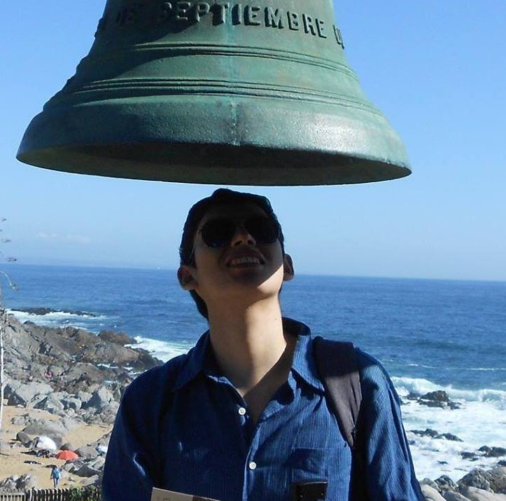

## Mauricio Toro Cea

- (casi casi) PhD en Estadística, PUC
- Académico Jornada Parcial, Facultad de Matemáticas, PUC

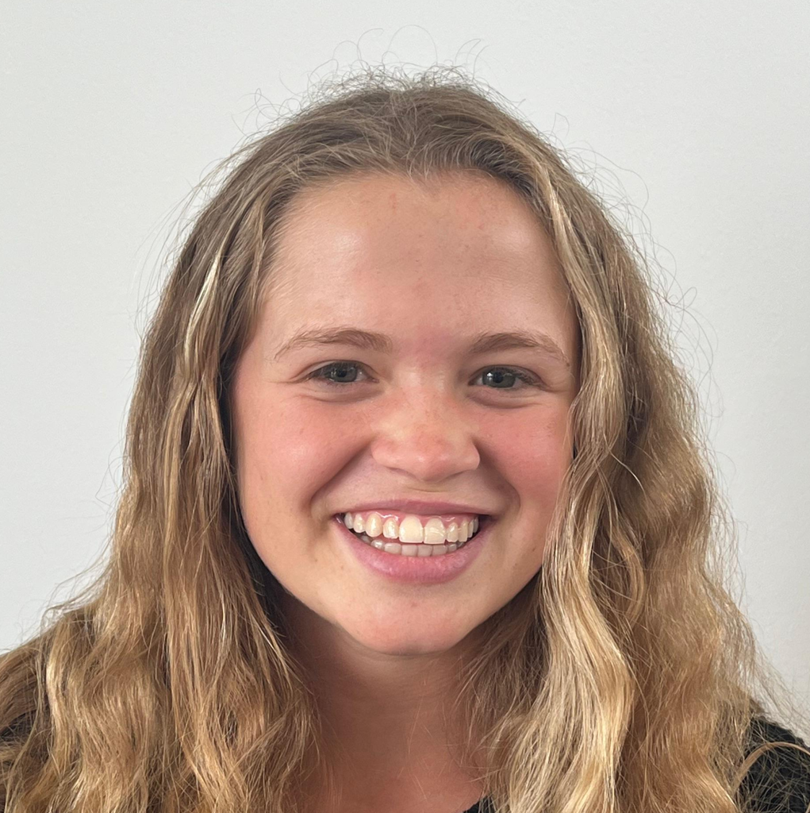

## Isidora González

- Profesora de Educación General Básica mención Matemática, PUC
- Colegio Sagrado Corazón de la Reina, Región Metropolitana

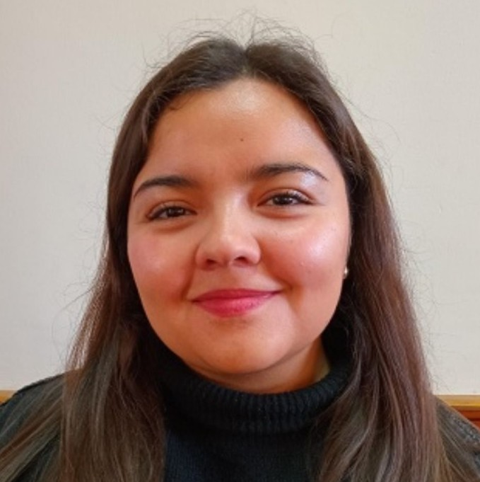

## Javiera Castillo

- Profesora de Educación General Básica mención Matemática, PUC
- Colegio Inmaculada Concepción de San Fernando, Región de O'Higgins

## Introducción

## Necesidad de la innovación

> **MA06 OA 23** - Conjeturar acerca de la tendencia de resultados obtenidos en repeticiones de un mismo experimento con dados, monedas u otros, de manera manual y/o usando software educativo (Ministerio de Educación de Chile, 2024).

## Necesidad de la innovación

### Software educativo permite:

⚡

#### Automatización

Miles de repeticiones  
Tablas y gráficos automáticos

→

🧠

#### Interpretación

Enfoque total en el  
análisis de datos

## Necesidad de la innovación

- 💀 **Enlaces rotos**: referencias en textos caídas o desactualizadas (ej. Osorio Angarita et al., 2013)
- 💻 **Conocimientos de programación**: Su uso puede exigir manejar código (ej. R, Python, GeoGebra)
- ⚙️ Applets existentes **difíciles de modificar/personalizar**
  - Ejemplos GeoGebra: [Ejemplo 1](https://www.geogebra.org/m/cSfwCRkM), [Ejemplo 2](https://www.geogebra.org/m/uekzrm6e)
  - Ejemplo [R/Shiny](https://jasondouglasgibbs.shinyapps.io/DiceRollingApp/)

## Necesidad de la innovación

- Accesible  
  💲 🏫  
  👨‍🏫 🧑‍🎓 ️
- Fácil de Usar  
  🖱️
- Interactiva  
  💡

**Idea**: usar una Inteligencia Artificial (IA) generativa como alternativa.

## Pregunta de Innovación

¿Puede la IA generativa favorecer la comprensión de los conceptos abstractos de frecuencia relativa, probabilidad teórica, variabilidad y tendencia?

## Aspectos Metodológicos

## Conceptos Estadísticos

- **Experimento (aleatorio)**: Es cualquier experiencia que tiene más de un resultado posible y que, al ser realizada, no se sabe cuál de sus resultados va ocurrir pues ello es producto del azar (Ministerio de Educación de Chile, 2019b).
- **Espacio Muestral**: Conjunto de todos los resultados posibles de un experimento aleatorio (Ministerio de Educación de Chile, 2019b). \[\Omega = \{ ⚀, ⚁ ,⚂ ,⚃ ,⚄, ⚅ \}\]
- **Evento elemental**: Elemento del Espacio Muestral. Es uno de los resultados posibles de un experimento aleatorio.

## Conceptos Estadísticos

- **Datos**: Resultados obtenidos al repetir un experimento aleatorio.
- **Frecuencia absoluta**: Es el número de veces que se repite cada dato (Ministerio de Educación de Chile, 2019a).
- **Frecuencia relativa**: Es el cociente de la frecuencia absoluta por el total de repeticiones del experimento aleatorio.

🎲 ➔ 📊

## Conceptos Estadísticos

- **Probabilidad de un evento elemental**: Valor que varía de 0 a 1 que corresponde al valor hacia el cual se observa que la frecuencia relativa tiende a estabilizarse, cuando se realiza el experimento aleatorio una gran cantidad de veces (Ministerio de Educación de Chile, 2019b).
- **Regla de Laplace**: Si los eventos elementales tienen igual probabilidad, entonces la probabilidad de cada resultado posible es \[ \frac{1}{\text{Número total de casos posibles}} \]

## COPISI

La actividad fue diseñada, siguiendo el modelo COPISI (Bruner, 1966), en tres fases:

- **Fase concreta**: Los estudiantes recogen datos mediante experimentos físicos (lanzamiento de dados).
- **Fase pictórica (Potenciada por IA)**: El docente usa IA para generar un gráfico de barras con los datos recolectados.
- **Fase simbólica/abstracta**: Con la IA se simulan miles de repeticiones del experimento y se presenta su gráfico correspondiente. Discusión guiada sobre: relación entre frecuencias experimental y teórica; frecuencias relativas ante muchísimas repeticiones.

## Inteligencia Artificial (IA) generativa Conceptos

- **IA generativa** 🤖  
  Modelo de Inteligencia Artificial (IA) capaz de producir contenido nuevo —como texto, imágenes o código— (Harvard University Information Technology, s. f.).
- **LLM (Large Language Model)** 🧠  
  Modelo de IA entrenado con enormes volúmenes de texto para predecir la siguiente unidad de texto (token) dentro de una secuencia. Gracias a su escala, datos y arquitectura —generalmente basada en *transformers*— los LLMs pueden responder preguntas, redactar textos, traducir, resumir y realizar muchas otras tareas lingüísticas gracias a patrones aprendidos durante su entrenamiento.

## Inteligencia Artificial (IA) generativa Conceptos

- **Prompt** ✍️  
  Entrada que el usuario entrega al modelo para indicar qué desea obtener. Puede incluir instrucciones, contexto, formato esperado e incluso ejemplos. La forma en que se redacta influye directamente en la calidad del resultado (MIT Sloan Teaching & Learning Technologies, s. f.-a).
- **Ingeniería de prompts (prompt engineering)** 🛠️  
  Conjunto de estrategias para diseñar prompts efectivos, con el fin de guiar al modelo hacia respuestas más útiles, precisas y consistentes (Stanford University, 2024; University of Texas at Austin, 2025).

## Inteligencia Artificial (IA) generativa Conceptos

- **Alucinación** ⚠️  
  Situación en la que el modelo produce información incorrecta, inexistente o inventada, aunque suene plausible. Es un comportamiento esperado en modelos generativos y requiere supervisión crítica del usuario (MIT Sloan Teaching & Learning Technologies, s. f.-b; University of Illinois at Urbana-Champaign, 2025).
- **Markdown** 🧾  
  Es un sistema sencillo para escribir texto que luego puede mostrarse con formato —títulos, listas, negritas o tablas— usando solo caracteres comunes. Muchos visores de chats de IA generativas interpretan Markdown para dar estilo y estructura a sus respuestas (Gruber, John, s. f.).

## Inteligencia Artificial (IA) generativa Uso ético

- Las herramientas de IA pueden dar **resultados con errores**
- Es crucial el **uso ético de las herramientas de IA generativa** (Miao & Holmes, 2024; Ministerio de Educación, Centro de Innovación, 2025)
  - Resguardando la **privacidad**
  - Evitando sesgos
  - Supervisión humana (man in the loop) para detectar alucinaciones

## Inteligencia Artificial (IA) generativa Simulación computacional

- **Simulación computacional** 💻  
  Proceso de modelar y reproducir fenómenos del mundo real mediante algoritmos y programas de computadora (Purdue University, s. f.).
- **Semilla (seed)** 🎲  
  Valor que permite “congelar” la aleatoriedad de una simulación, de modo que cada vez que se ejecute se obtengan los mismos resultados. En Python, el comando para fijar una semilla es `numpy.random.seed(valor)` (NumPy Development Team, s. f.).

## Diseño de la Actividad Aspectos clave para elegir herramienta IA

- **Privacidad**: Preferir herramientas de IA que pueden ser usadas sin autenticación.
- **Replicabilidad**: Considerar solo herramientas capaces de generar y ejecutar código Python.
- **Visualización de resultados**: Preferir herramientas capaces de incluir en el chat, en sus respuestas, tablas y gráficos generados por Python.

## Diseño de la Actividad Elección de herramienta IA

A la fecha (noviembre de 2025), la única IA generativa que cumple los criterios de privacidad, replicabilidad y visualización es [Copilot](https://copilot.microsoft.com/).

**Tabla 1. Comparación de herramientas de IA que permiten hacer consultas sin autenticación. Información actualizada a noviembre de 2025.**

[output not shown]

## Diseño de la Actividad Criterios de Diseño del Prompt

- lo más conciso posible;
- comprensible para los estudiantes; e
- incluir vocabulario técnico solo cuando es indispensable.

## Diseño de la Actividad Prompt Engineering

Para comprobar la **replicabilidad** de las respuestas:

- Incluir en el prompt la especificación explícita de la **semilla** a utilizar.
- Verificar que las respuestas del modelo coincidan con las que deberían generarse usando esa semilla.
- Cuando sea necesario, ejecutar el código Python generado por la IA (de manera local o en [Google Colab](https://colab.research.google.com/)).

**Ejecutar el prompt varias veces** en distintos chats sin iniciar sesión (idealmente usando el navegador en *modo incógnito*).

## Diseño de la Actividad Proceso de validación

- Genera y ejecuta código Python.
- Datos son simulados usando la semilla especificada.
- Muestra tabla y gráfico en chat.

## Diseño de la Actividad Ejemplo de prompt validado

```
Simula 1000 lanzamientos de un dado justo de 6 caras. Usa Python con semilla 42.
En tu respuesta incluye una tabla Markdown con columnas: Número | Frecuencia | Frecuencia relativa | Probabilidad teórica.
Genera un gráfico de barras con la frecuencia relativa por número. Incrusta el gráfico en tu respuesta.
```

- El prompt incluye `semilla 42` para verificar la reproductibilidad de los resultados.
- Se especifica que genere una tabla en formato **Markdown** para evitar alucinaciones.

## Diseño de la Actividad Ejemplo de prompt validado

[figure not shown]

## Actividad diseñada

## Etapas de la actividad

1. Definición y repaso de conceptos claves
2. Actividad 1: Lanzamiento manual de un Dado
   - Cálculo y reflexión sobre la probabilidad teórica
3. Actividad 2: Simulación con Inteligencia Artificial
   - 100 lanzamientos
   - 1000 lanzamientos
   - 10000 lanzamientos
4. Análisis y conjetura con IA
5. Cierre de la actividad

## Documentación

[figure not shown]

📄 Material disponible en el repositorio GitHub /mauriciotorocea/ActividadSimulacionDados

- 📘 Guía para estudiantes (versión 26/11/2025):
  - [descargar .docx](https://github.com/mauriciotorocea/ActividadSimulacionDados/raw/refs/heads/main/Gu%C3%ADa%206tos%20b%C3%A1sicos.docx).
- 👩‍🏫 Guía para el docente (versión 26/11/2025):
  - [descargar .docx](https://github.com/mauriciotorocea/ActividadSimulacionDados/raw/refs/heads/main/Gu%C3%ADa%20para%20el%20docente.docx).
- 🛠️ Guía técnica (versión 01/12/2025):
  - [ver versión html](https://mauriciotorocea.github.io/ActividadSimulacionDados/GuiaTecnica.html)
  - [descargar pdf](https://raw.githubusercontent.com/mauriciotorocea/ActividadSimulacionDados/main/GuiaTecnica.pdf).

## Aplicación

## Detalle cursos

| Fecha aplicación | Colegio | Curso | N° alumnos | N° participantes |
| --- | --- | --- | --- | --- |
| 26-11-2025 | Colegio Sagrado Corazón de la Reina, Región Metropolitana. | 6°A 💻 | 45 | 44 |
| 26-11-2025 | Colegio Sagrado Corazón de la Reina, Región Metropolitana. | 6°B 💻 | 45 | 43 |
| 03-12-2025 | Colegio Inmaculada Concepción de San Fernando, Región de O’Higgins. | 6°A 📱 | 40 | 10 |
| 04-12-2025 | Colegio Inmaculada Concepción de San Fernando, Región de O’Higgins. | 6°B 💻 | 40 | 10 |

## Fotos

[figure not shown]

[figure not shown]

[figure not shown]

## Concluye y comparte

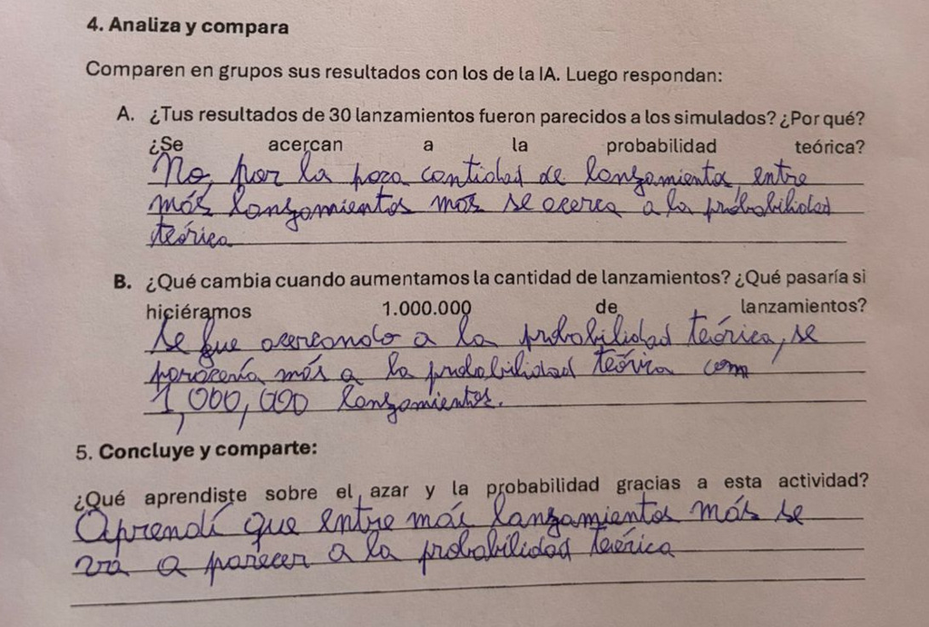

## Concluye y comparte

¿Conclusión propia o frase cursi de la IA?

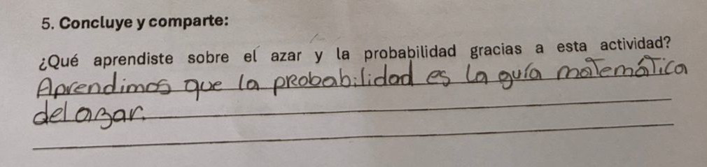

## Concluye y comparte

Variabilidad llevada al extremo…

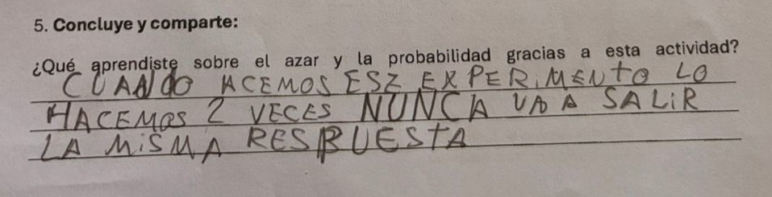

## Resultados

> ¡Vamos a usar la IA para que nos ayude a aprender más!

### ¿Cómo ven la IA los estudiantes?

- ¡Les gusta mucho la IA! 🤖
- Usar IA en el colegio… **era casi un pecado** ☠️.
- ➔ 🙏 Tendencia a pedir permiso para escribir más prompts.

### Computador versus teléfono: el tamaño de la pantalla *sí* importa

- 📱 Pantalla pequeña ➔ gráficos pequeños ➔ no todos pueden ver
- 💻 Pantalla grande ➔ mejor visión ➔ facilita el trabajo en equipo

## Resultados

La **comparación** de **simulaciones** con las frecuencias relativas de los **lanzamientos manuales** ayudó a que identificaran la **tendencia en las frecuencias relativas**.

- Estudiantes de colegio 1 **no sabían qué es un experimento (aleatorio)**
- **Costó más generar orden** en la sala de computación.

## Resultados

> Nunca nos habían hecho usar la IA en clases.

### Promoción de la participación:

- 💡 Estudiantes familiarizados con la IA supieron pedir más gráficos sin ayuda.
- 📝 En clases normales alumnos hacen cualquier cosa en su cuaderno.
- ✅ En esta actividad, todos contestaron la guía completa.
- **Aspecto negativo**: algunos grupos se lo tomaron como un juego 🎮. No se centraron en la guía.

## Conclusiones

## Conclusiones

🧑‍🎓

#### Sí

Fomentó que aprendieran por sí solos.

🔭

#### Sí

Niños compararon, analizaron y tuvieron una visión más amplia con las simulaciones.

## Referencias

Bruner, J. (1966). *Toward a Theory of Instruction*. Harvard University Press.

Gruber, John. (s. f.). *Markdown Syntax Documentation*. Recuperado 1 de diciembre de 2025, de https://daringfireball.net/projects/markdown/syntax

Harvard University Information Technology. (s. f.). *Generative Artificial Intelligence (AI)*. Recuperado 1 de diciembre de 2025, de https://www.huit.harvard.edu/ai

Miao, F., & Holmes, W. (2024). *Guía para el uso de IA generativa en educación e investigación*. UNESCO. https://unesdoc.unesco.org/ark:/48223/pf0000386696

Ministerio de Educación, Centro de Innovación. (2025). *PotencIA el aprendizaje: Preguntas para la reflexión y práctica de la Inteligencia Artificial generativa en contextos educativos*. Ciudadanía Digital. https://ciudadaniadigital.mineduc.cl/potencia-el-aprendizaje-ia-en-educacion/

Ministerio de Educación de Chile. (2019a). *Guía de Aprendizaje N°5: Estadística en la vida de hoy*. https://epja.mineduc.cl/wp-content/uploads/sites/43/2019/06/Guía-N°-5-Matemática-Estadística-en-la-vida-de-hoy.pdf.

Ministerio de Educación de Chile. (2019b). *Guía de Aprendizaje N°6: Azar y Probabilidad*. https://epja.mineduc.cl/wp-content/uploads/sites/43/2019/06/Guía-N°-6-Matemática-Azar-y-probabilidad.pdf.

Ministerio de Educación de Chile. (2024). *Bases Curriculares Primero a Sexto Básico*. MINEDUC.

MIT Sloan Teaching & Learning Technologies. (s. f.-a). *Effective Prompts for AI: The Essentials*. Recuperado 1 de diciembre de 2025, de https://mitsloanedtech.mit.edu/ai/basics/effective-prompts/

MIT Sloan Teaching & Learning Technologies. (s. f.-b). *When AI Gets It Wrong: Addressing AI Hallucinations and Bias*. Recuperado 1 de diciembre de 2025, de https://mitsloanedtech.mit.edu/ai/basics/addressing-ai-hallucinations-and-bias/

NumPy Development Team. (s. f.). *NumPy Documentation — numpy.random.seed*. https://numpy.org/doc/stable/reference/random/generated/numpy.random.seed.html.

Osorio Angarita, M. A., Suárez Parra, A., & Uribe Sandoval, C. C. (2013). Revisión de alternativas propuestas para mejorar el aprendizaje de la Probabilidad. *Revista Virtual Universidad Católica del Norte*. https://www.redalyc.org/articulo.oa?id=194225730010

Purdue University. (s. f.). *Week 13 - Simulation*. Recuperado 1 de diciembre de 2025, de https://engineering.purdue.edu/~engelb/abe565/week13.htm

Stanford University. (2024). *AI Demystified: What is Prompt Engineering?* https://uit.stanford.edu/service/techtraining/ai-demystified/prompt-engineering

University of Illinois at Urbana-Champaign. (2025). *Hallucinations - Introduction to Generative AI - LibGuides at University of Illinois at Urbana-Champaign*. https://guides.library.illinois.edu/generativeAI/hallucinations

University of Texas at Austin. (2025). *Prompt Engineering - Artificial Intelligence (AI) - LibGuides at University of Texas at Austin*. https://guides.lib.utexas.edu/AI/prompt-engineering

[figure not shown]

# Repetición de experimentos con estudiantes de 6° básico e Inteligencia Artificial Generativa

Mauricio Toro (torocea@ uc.cl), Isidora González y Javiera Castillo  
Jornadas Nacionales de Educación Estadística  
15 y 16 de diciembre 2025, Valparaíso, Chile